# Assignment 6: Apply NB

1. Minimum data points need to be considered for people having 4GB RAM is **50k** and for 8GB RAM is **100k**
2. When you are using ramdomsearchcv or gridsearchcv you need not split the data into X_train,X_cv,X_test. As the above methods use kfold. The model will learn better if train data is more so splitting to X_train,X_test will suffice.
3. If you are writing for loops to tune your model then you need split the data into X_train,X_cv,X_test.
4. While splitting the data explore stratify parameter.
5. **Apply Multinomial NB on these feature sets**
- Features that need to be considered

**essay**

while encoding essay, try to experiment with the max_features and n_grams parameter of vectorizers and see if it increases AUC score.

**categorical features**

- teacher_prefix

- project_grade_category

- school_state

- clean_categories

- clean_subcategories

**numerical features**

- price

- teacher_number_of_previously_posted_projects

while encoding the numerical features check [this](https://imgur.com/ldZA1zg) and [this](https://ac-classroom-production.s3.amazonaws.com/public/COMMENT/Annotation_2020-05-21_225912_0lyZzN8.jpg)

- Set 1: categorical, numerical features + preprocessed_eassay (BOW)
- Set 2: categorical, numerical features + preprocessed_eassay (TFIDF)
6. **The hyper paramter tuning(find best alpha:smoothing parameter)**
   - Consider alpha values in range: 10^-5 to 10^2 like [0.00001,0.0005, 0.0001,0.005,0.001,0.05,0.01,0.1,0.5,1,5,10,50,100]
   - Explore class_prior = [0.5, 0.5] parameter which can be present in MultinomialNB function(go through [this](https://scikit-learn.org/stable/modules/generated/sklearn.naive_bayes.MultinomialNB.html) ) then check how results might change.
   - Find the best hyper parameter which will give the maximum [AUC](https://www.appliedaicourse.com/course/applied-ai-course-online/lessons/receiver-operating-characteristic-curve-roc-curve-and-auc-1/) value
   - For hyper parameter tuning using k-fold cross validation(use GridsearchCV or RandomsearchCV)/simple cross validation data (write for loop to iterate over hyper parameter values)
   - You need to plot the performance of model both on train data and cross validation data for each hyper parameter, like shown in the figure

[figure not shown]

     -while plotting take log(alpha) on your X-axis so that it will be more readable
   - Once after you found the best hyper parameter, you need to train your model with it, and find the AUC on test data and plot the ROC curve on both train and test.

[figure not shown]

   - Along with plotting ROC curve, you need to print the [confusion matrix](https://www.appliedaicourse.com/course/applied-ai-course-online/lessons/confusion-matrix-tpr-fpr-fnr-tnr-1/) with predicted and original labels of test data points

[figure not shown]

     -plot the confusion matrix in heatmaps, while plotting the confusion matrix go through the [link](https://stackoverflow.com/questions/61748441/how-to-fix-the-values-displayed-in-a-confusion-matrix-in-exponential-form-to-nor)
7. find the top 20 features from either from feature Set 1 or feature Set 2 using values of `feature_log_prob_ ` parameter of `MultinomialNB` (https://scikit-learn.org/stable/modules/generated/sklearn.naive_bayes.MultinomialNB.html) and print **BOTH** positive as well as negative corresponding feature names.

   - go through the [link](https://imgur.com/mWvE7gj)
8. You need to summarize the results at the end of the notebook, summarize it in the table format

[figure not shown]

# 2. Naive Bayes

## 1.1 Loading Data

```python
%matplotlib inline
import warnings
warnings.filterwarnings("ignore")

import pandas as pd
import numpy as np
import nltk
import matplotlib.pyplot as plt
import seaborn as sns
from sklearn.feature_extraction.text import TfidfVectorizer
from sklearn.feature_extraction.text import CountVectorizer
from sklearn.metrics import confusion_matrix
from sklearn import metrics
from sklearn.metrics import roc_curve, auc

import re
# Tutorial about Python regular expressions: https://pymotw.com/2/re/

import pickle
from tqdm import tqdm
import os
from sklearn import preprocessing

import chart_studio.plotly as plotly
import plotly.offline as offline
import plotly.graph_objs as go
offline.init_notebook_mode()
from collections import Counter
```

```python
data  = pd.read_csv('preprocessed_data2.csv', nrows=50000)
data.head(5)
```

|  | teacher_prefix | school_state | project_grade_category | project_subject_categories | project_subject_subcategories | project_title | project_resource_summary | teacher_number_of_previously_posted_projects | project_is_approved | essay | price |
| --- | --- | --- | --- | --- | --- | --- | --- | --- | --- | --- | --- |
| 0 | mrs | in | grades_prek_2 | literacy_language | esl_literacy | Educational Support for English Learners at Home | My students need opportunities to practice beg... | 0 | 0 | My students are English learners that are work... | 154.60 |
| 1 | mr | fl | grades_6_8 | history_civics_health_sports | civics_government_teamsports | Wanted: Projector for Hungry Learners | My students need a projector to help with view... | 7 | 1 | Our students arrive to our school eager to lea... | 299.00 |
| 2 | ms | az | grades_6_8 | health_sports | health_wellness_teamsports | Soccer Equipment for AWESOME Middle School Stu... | My students need shine guards, athletic socks,... | 1 | 0 | \r\n\"True champions aren't always the ones th... | 516.85 |
| 3 | mrs | ky | grades_prek_2 | literacy_language_math_science | literacy_mathematics | Techie Kindergarteners | My students need to engage in Reading and Math... | 4 | 1 | I work at a unique school filled with both ESL... | 232.90 |
| 4 | mrs | tx | grades_prek_2 | math_science | mathematics | Interactive Math Tools | My students need hands on practice in mathemat... | 1 | 1 | Our second grade classroom next year will be m... | 67.98 |

```python
print("Number of data points in train data", data.shape)
print('-'*50)
print("The attributes of data :", data.columns.values)
```

```
Number of data points in train data (50000, 11)
--------------------------------------------------
The attributes of data : ['teacher_prefix' 'school_state' 'project_grade_category'
 'project_subject_categories' 'project_subject_subcategories'
 'project_title' 'project_resource_summary'
 'teacher_number_of_previously_posted_projects' 'project_is_approved'
 'essay' 'price']
```

```python
# check if we have any nan values are there
print(data['project_title'].isnull().values.any())
print("number of nan values",data['project_title'].isnull().values.sum())
```

```
False
number of nan values 0
```

```python
y = data['project_is_approved'].values
X = data.drop(['project_is_approved'], axis=1)
X.head(1)
```

|  | teacher_prefix | school_state | project_grade_category | project_subject_categories | project_subject_subcategories | project_title | project_resource_summary | teacher_number_of_previously_posted_projects | essay | price |
| --- | --- | --- | --- | --- | --- | --- | --- | --- | --- | --- |
| 0 | mrs | in | grades_prek_2 | literacy_language | esl_literacy | Educational Support for English Learners at Home | My students need opportunities to practice beg... | 0 | My students are English learners that are work... | 154.6 |

## 1.2 Splitting data into Train and cross validation(or test): Stratified Sampling

```python
# train test split
from sklearn.model_selection import train_test_split
X_train, X_test, y_train, y_test = train_test_split(X, y, test_size=0.33, stratify=y)
X_train, X_cv, y_train, y_cv = train_test_split(X_train, y_train, test_size=0.33, stratify=y_train)
```

## 1.3 Make Data Model Ready: encoding eassay, and project_title

```python
print(X_train.shape, y_train.shape)
print(X_cv.shape, y_cv.shape)
print(X_test.shape, y_test.shape)

print("="*100)


vectorizer_1 = CountVectorizer(min_df=10,ngram_range=(1,4), max_features=5000)
vectorizer_1.fit(X_train['essay'].values) # fit has to happen only on train data

# we use the fitted CountVectorizer to convert the text to vector
X_train_essay_bow = vectorizer_1.transform(X_train['essay'].values)
X_cv_essay_bow = vectorizer_1.transform(X_cv['essay'].values)
X_test_essay_bow = vectorizer_1.transform(X_test['essay'].values)

print("After vectorizations")
print(X_train_essay_bow.shape, y_train.shape)
print(X_cv_essay_bow.shape, y_cv.shape)
print(X_test_essay_bow.shape, y_test.shape)
print("="*100)
```

```
(22445, 10) (22445,)
(11055, 10) (11055,)
(16500, 10) (16500,)
====================================================================================================
After vectorizations
(22445, 5000) (22445,)
(11055, 5000) (11055,)
(16500, 5000) (16500,)
====================================================================================================
```

```python
vectorizer_2 = CountVectorizer(max_features=500)
vectorizer_2.fit(X_train['project_title'].values) # fit has to happen only on train data

# we use the fitted CountVectorizer to convert the text to vector
X_train_title_bow = vectorizer_2.transform(X_train['project_title'].values)
X_cv_title_bow = vectorizer_2.transform(X_cv['project_title'].values)
X_test_title_bow = vectorizer_2.transform(X_test['project_title'].values)

print("After vectorizations")
print(X_train_title_bow.shape, y_train.shape)
print(X_cv_title_bow.shape, y_cv.shape)
print(X_test_title_bow.shape, y_test.shape)
print("="*100)
```

```
After vectorizations
(22445, 500) (22445,)
(11055, 500) (11055,)
(16500, 500) (16500,)
====================================================================================================
```

## 1.4 Make Data Model Ready: encoding numerical, categorical features

### 1.4.1 encoding categorical features: School State

```python
vectorizer_3 = CountVectorizer()
vectorizer_3.fit(X_train['school_state'].values) # fit has to happen only on train data

# we use the fitted CountVectorizer to convert the text to vector
X_train_state_ohe = vectorizer_3.transform(X_train['school_state'].values)
X_cv_state_ohe = vectorizer_3.transform(X_cv['school_state'].values)
X_test_state_ohe = vectorizer_3.transform(X_test['school_state'].values)

print("After vectorizations")
print(X_train_state_ohe.shape, y_train.shape)
print(X_cv_state_ohe.shape, y_cv.shape)
print(X_test_state_ohe.shape, y_test.shape)
```

```
After vectorizations
(22445, 51) (22445,)
(11055, 51) (11055,)
(16500, 51) (16500,)
```

### 1.4.2 encoding categorical features: teacher_prefix

```python
vectorizer_4 = CountVectorizer()
vectorizer_4.fit(X_train['teacher_prefix'].values) # fit has to happen only on train data

# we use the fitted CountVectorizer to convert the text to vector
X_train_teacher_ohe = vectorizer_4.transform(X_train['teacher_prefix'].values)
X_cv_teacher_ohe = vectorizer_4.transform(X_cv['teacher_prefix'].values)
X_test_teacher_ohe = vectorizer_4.transform(X_test['teacher_prefix'].values)

print("After vectorizations")
print(X_train_teacher_ohe.shape, y_train.shape)
print(X_cv_teacher_ohe.shape, y_cv.shape)
print(X_test_teacher_ohe.shape, y_test.shape)
```

```
After vectorizations
(22445, 4) (22445,)
(11055, 4) (11055,)
(16500, 4) (16500,)
```

### 1.4.3 encoding categorical features: project_grade_category

```python
vectorizer_5 = CountVectorizer()
vectorizer_5.fit(X_train['project_grade_category'].values) # fit has to happen only on train data

# we use the fitted CountVectorizer to convert the text to vector
X_train_grade_ohe = vectorizer_5.transform(X_train['project_grade_category'].values)
X_cv_grade_ohe = vectorizer_5.transform(X_cv['project_grade_category'].values)
X_test_grade_ohe = vectorizer_5.transform(X_test['project_grade_category'].values)

print("After vectorizations")
print(X_train_grade_ohe.shape, y_train.shape)
print(X_cv_grade_ohe.shape, y_cv.shape)
print(X_test_grade_ohe.shape, y_test.shape)
```

```
After vectorizations
(22445, 4) (22445,)
(11055, 4) (11055,)
(16500, 4) (16500,)
```

### 1.4.4 encoding categorical features: project_subject_categories

```python
vectorizer_6 = CountVectorizer()
vectorizer_6.fit(X_train['project_subject_categories'].values) # fit has to happen only on train data

# we use the fitted CountVectorizer to convert the text to vector
X_train_subject_categories = vectorizer_6.transform(X_train['project_subject_categories'].values)
X_cv_subject_categories = vectorizer_6.transform(X_cv['project_subject_categories'].values)
X_test_subject_categories = vectorizer_6.transform(X_test['project_subject_categories'].values)

print("After vectorizations")
print(X_train_subject_categories.shape, y_train.shape)
print(X_cv_subject_categories.shape, y_cv.shape)
print(X_test_subject_categories.shape, y_test.shape)
```

```
After vectorizations
(22445, 50) (22445,)
(11055, 50) (11055,)
(16500, 50) (16500,)
```

### 1.4.5 encoding categorical features: project_subject_subcategories

```python
vectorizer_7 = CountVectorizer(max_features=100)
vectorizer_7.fit(X_train['project_subject_subcategories'].values) # fit has to happen only on train data

# we use the fitted CountVectorizer to convert the text to vector
X_train_subject_subcategories = vectorizer_7.transform(X_train['project_subject_subcategories'].values)
X_cv_subject_subcategories = vectorizer_7.transform(X_cv['project_subject_subcategories'].values)
X_test_subject_subcategories = vectorizer_7.transform(X_test['project_subject_subcategories'].values)

print("After vectorizations")
print(X_train_subject_subcategories.shape, y_train.shape)
print(X_cv_subject_subcategories.shape, y_cv.shape)
print(X_test_subject_subcategories.shape, y_test.shape)
```

```
After vectorizations
(22445, 100) (22445,)
(11055, 100) (11055,)
(16500, 100) (16500,)
```

### 1.4.6 encoding numerical features: Price

```python
from sklearn.preprocessing import Normalizer
normalizer = Normalizer()
# normalizer.fit(X_train['price'].values)
# this will rise an error Expected 2D array, got 1D array instead:
# array=[105.22 215.96  96.01 ... 368.98  80.53 709.67].
# Reshape your data either using
# array.reshape(-1, 1) if your data has a single feature
# array.reshape(1, -1)  if it contains a single sample.
normalizer.fit(X_train['price'].values.reshape(1,-1))

X_train_price_norm = normalizer.transform(X_train['price'].values.reshape(1,-1))
X_cv_price_norm = normalizer.transform(X_cv['price'].values.reshape(1,-1))
X_test_price_norm = normalizer.transform(X_test['price'].values.reshape(1,-1))



print("After vectorizations")
print(X_train_price_norm.shape, y_train.shape)
print(X_cv_price_norm.shape, y_cv.shape)
print(X_test_price_norm.shape, y_test.shape)
print("="*100)
```

```
After vectorizations
(1, 22445) (22445,)
(1, 11055) (11055,)
(1, 16500) (16500,)
====================================================================================================
```

```python
#we are defining this function to return arrray
def to_array(a):
  b = a.tolist()
  c = []
  for i in b:
    for  j in i:
      c.append(j)
  d = [i for i in range(len(c))]
  df = pd.DataFrame(list(zip(d, c)),columns = ['1','2'])
  e = df.drop(['1'], axis=1)
  array = e.to_numpy()

  return array
```

```python
X_train_price_norm_array = to_array(X_train_price_norm)
X_cv_price_norm_array = to_array(X_cv_price_norm)
X_test_price_norm_array = to_array(X_test_price_norm)
```

### 1.4.7 Concatinating all the features

```python
# merge two sparse matrices: https://stackoverflow.com/a/19710648/4084039
from scipy.sparse import hstack
X_tr = hstack((X_train_essay_bow,X_train_title_bow, X_train_state_ohe,X_train_subject_categories,X_train_subject_subcategories, X_train_teacher_ohe, X_train_grade_ohe)).tocsr()
X_cr = hstack((X_cv_essay_bow,X_cv_title_bow, X_cv_state_ohe,X_cv_subject_categories,X_cv_subject_subcategories ,X_cv_teacher_ohe, X_cv_grade_ohe)).tocsr()
X_te = hstack((X_test_essay_bow,X_test_title_bow, X_test_state_ohe,X_test_subject_categories,X_test_subject_subcategories, X_test_teacher_ohe, X_test_grade_ohe)).tocsr()

print("Final Data matrix")
print(X_tr.shape, y_train.shape)
print(X_cr.shape, y_cv.shape)
print(X_te.shape, y_test.shape)
print("="*100)
```

```
Final Data matrix
(22445, 5709) (22445,)
(11055, 5709) (11055,)
(16500, 5709) (16500,)
====================================================================================================
```

```python
X_tr1 = X_tr.toarray()
#Normalize Data
X_tr1 = preprocessing.normalize(X_tr1)
X_tr2 = np.concatenate((X_tr1, X_train_price_norm_array), axis=1)


X_cr1 = X_cr.toarray()
#Normalize Data
X_cr1 = preprocessing.normalize(X_cr1)
X_cr2 = np.concatenate((X_cr1, X_cv_price_norm_array), axis=1)


X_te1 = X_te.toarray()
#Normalize Data
X_te1 = preprocessing.normalize(X_te1)
X_te2 = np.concatenate((X_te1, X_test_price_norm_array), axis=1)
```

```python
def batch_predict(clf, data):
    # roc_auc_score(y_true, y_score) the 2nd parameter should be probability estimates of the positive class
    # not the predicted outputs

    y_data_pred = []
    tr_loop = data.shape[0] - data.shape[0]%1000
    # consider you X_tr shape is 49041, then your tr_loop will be 49041 - 49041%1000 = 49000
    # in this for loop we will iterate unti the last 1000 multiplier
    for i in range(0, tr_loop, 1000):
        y_data_pred.extend(clf.predict_proba(data[i:i+1000])[:,1])
    # we will be predicting for the last data points
    if data.shape[0]%1000 !=0:
        y_data_pred.extend(clf.predict_proba(data[tr_loop:])[:,1])

    return y_data_pred
```

```python
def Confusion_matrix(y_test, test_pred):
  # Confusion matrix for test data
  plt.figure()
  cm = confusion_matrix(y_test, test_pred)
  class_label = ["negative", "positive"]
  df_cm_test = pd.DataFrame(cm, index = class_label, columns = class_label)
  sns.heatmap(df_cm_test , annot = True, fmt = "d")
  plt.title("Confusiion Matrix for test data")
  plt.xlabel("Predicted Label")
  plt.ylabel("True Label")
  plt.show()
```

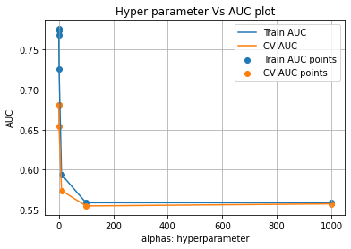

|  | mean_fit_time | std_fit_time | mean_score_time | std_score_time | param_alpha | split0_test_score | split1_test_score | split2_test_score | mean_test_score | std_test_score | rank_test_score | split0_train_score | split1_train_score | split2_train_score | mean_train_score | std_train_score | params |
| --- | --- | --- | --- | --- | --- | --- | --- | --- | --- | --- | --- | --- | --- | --- | --- | --- | --- |
| 0 | 0.947855 | 0.545992 | 0.124796 | 0.001595 | 0.0001 | 0.681987 | 0.675024 | 0.686037 | 0.681016 | 0.004548 | 3 | 0.774743 | 0.777720 | 0.774635 | 0.775700 | 0.001430 | 0.0001 |
| 1 | 0.546391 | 0.002946 | 0.125135 | 0.002679 | 0.001 | 0.682472 | 0.675513 | 0.686167 | 0.681384 | 0.004417 | 2 | 0.774448 | 0.777171 | 0.774173 | 0.775264 | 0.001353 | 0.0010 |
| 2 | 0.543596 | 0.014811 | 0.125898 | 0.006619 | 0.01 | 0.682656 | 0.675740 | 0.686108 | 0.681501 | 0.004311 | 1 | 0.773496 | 0.775905 | 0.773070 | 0.774157 | 0.001248 | 0.0100 |
| 3 | 0.552372 | 0.008895 | 0.122491 | 0.001633 | 0.1 | 0.680470 | 0.673429 | 0.684053 | 0.679317 | 0.004413 | 4 | 0.767904 | 0.769902 | 0.767238 | 0.768348 | 0.001132 | 0.1000 |
| 4 | 0.553236 | 0.006184 | 0.124252 | 0.002827 | 1 | 0.655009 | 0.646988 | 0.661556 | 0.654518 | 0.005958 | 5 | 0.726160 | 0.728703 | 0.722907 | 0.725923 | 0.002372 | 1.0000 |

```python
# https://scikit-learn.org/stable/modules/generated/sklearn.model_selection.GridSearchCV.html
from sklearn.model_selection import GridSearchCV
from scipy.stats import randint as sp_randint
from sklearn.model_selection import RandomizedSearchCV
from sklearn.naive_bayes import MultinomialNB

NB = MultinomialNB()
#parameters = {'alphas':[0.0001*pow(10,i) for i in range(8)]}
alphas =  np.array([0.0001*pow(10,i) for i in range(8)])
parameters = {'alpha':alphas}
clf = RandomizedSearchCV(NB, parameters, cv=3, scoring='roc_auc',return_train_score=True)
clf.fit(X_tr2, y_train)

results = pd.DataFrame.from_dict(clf.cv_results_)

alphas_li = [row['params']['alpha'] for i, row in results.iterrows()]

results = results.drop(['params'], axis=1)


alphas_df= pd.DataFrame({'params':alphas_li})

frames = [results, alphas_df]

results = pd.concat(frames,axis=1)

results = results.sort_values(by = ['params'])

train_auc= results['mean_train_score']
train_auc_std= results['std_train_score']
cv_auc = results['mean_test_score']
cv_auc_std= results['std_test_score']
alphas =  results['params']

plt.plot(alphas, train_auc, label='Train AUC')
# this code is copied from here: https://stackoverflow.com/a/48803361/4084039
# plt.gca().fill_between(K, train_auc - train_auc_std,train_auc + train_auc_std,alpha=0.2,color='darkblue')

plt.plot(alphas, cv_auc, label='CV AUC')
# this code is copied from here: https://stackoverflow.com/a/48803361/4084039
# plt.gca().fill_between(K, cv_auc - cv_auc_std,cv_auc + cv_auc_std,alpha=0.2,color='darkorange')

plt.scatter(alphas, train_auc, label='Train AUC points')
plt.scatter(alphas, cv_auc, label='CV AUC points')


plt.legend()
plt.xlabel("alphas: hyperparameter")
plt.ylabel("AUC")
plt.title("Hyper parameter Vs AUC plot")
plt.grid()
plt.show()

results.head()
```

#### 1.5.1.2 Testing the performance of the model on test data, plotting ROC Curves

```python
#here we are choosing the best_alpha based on forloop results
best_alpha = clf.best_params_['alpha']
print(f'Best alpha is found to be {best_alpha}')
```

```
Best alpha is found to be 0.01
```

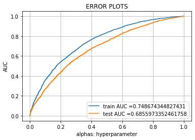

```python
# https://scikit-learn.org/stable/modules/generated/sklearn.metrics.roc_curve.html#sklearn.metrics.roc_curve
from sklearn.metrics import roc_curve, auc

NB = MultinomialNB(alpha = best_alpha)
#neigh = KNeighborsClassifier(n_neighbors=best_k, n_jobs=-1)
NB.fit(X_tr2, y_train)
# roc_auc_score(y_true, y_score) the 2nd parameter should be probability estimates of the positive class
# not the predicted outputs

y_train_pred = batch_predict(NB, X_tr2)
y_test_pred = batch_predict(NB, X_te2)

train_fpr, train_tpr, tr_thresholds = roc_curve(y_train, y_train_pred)
test_fpr, test_tpr, te_thresholds = roc_curve(y_test, y_test_pred)

plt.plot(train_fpr, train_tpr, label="train AUC ="+str(auc(train_fpr, train_tpr)))
plt.plot(test_fpr, test_tpr, label="test AUC ="+str(auc(test_fpr, test_tpr)))
plt.legend()
plt.xlabel("alphas: hyperparameter")
plt.ylabel("AUC")
plt.title("ERROR PLOTS")
plt.grid()
plt.show()
```

```python
# we are writing our own function for predict, with defined thresould
# we will pick a threshold that will give the least fpr
def find_best_threshold(threshould, fpr, tpr):
    t = threshould[np.argmax(tpr*(1-fpr))]
    # (tpr*(1-fpr)) will be maximum if your fpr is very low and tpr is very high
    print("the maximum value of tpr*(1-fpr)", max(tpr*(1-fpr)), "for threshold", np.round(t,3))
    return t

def predict_with_best_t(proba, threshould):
    predictions = []
    for i in proba:
        if i>=threshould:
            predictions.append(1)
        else:
            predictions.append(0)
    return predictions
```

```
====================================================================================================
the maximum value of tpr*(1-fpr) 0.46960816686890905 for threshold 0.84
Train confusion matrix
```

[figure not shown]

```
Test confusion matrix
```

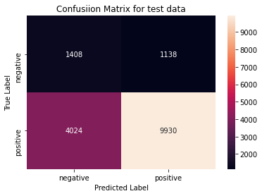

```python
print("="*100)
from sklearn.metrics import confusion_matrix
best_t = find_best_threshold(tr_thresholds, train_fpr, train_tpr)
print("Train confusion matrix")
Confusion_matrix(y_train, predict_with_best_t(y_train_pred, best_t))
print("Test confusion matrix")
Confusion_matrix(y_test, predict_with_best_t(y_test_pred, best_t))
```

```python
list_vectorizer = [vectorizer_1,vectorizer_2,vectorizer_3,vectorizer_4,vectorizer_5,vectorizer_6,vectorizer_7]
def top_20_features(transform,X_train,y_train,optimal_alpha):
  feature_name = []
  for i in transform:
    feature_name.extend(i.get_feature_names())

  feature_name.append('price')


  NB_optimal = MultinomialNB(alpha =optimal_alpha)
  NB_optimal.fit(X_train, y_train)

  # it gives Empirical log probability of features given a class (P(x_i|y))

  log_probability = NB_optimal.feature_log_prob_

  feature_probability_table = pd.DataFrame(log_probability, columns = feature_name)
  feature_prob_transpose = feature_probability_table.T

  print("Top 20 Negative Features:-\n",feature_prob_transpose[0].sort_values(ascending = False)[0:20])
  print("\n Top 20 Positive Features:-\n",feature_prob_transpose[1].sort_values(ascending = False)[0:20])
```

```python
top_20_features(list_vectorizer,X_tr2,y_train,0.01)
```

```
Top 20 Negative Features:-
 to            -3.494245
and           -3.652191
the           -3.774983
students      -3.974735
of            -4.214012
in            -4.275673
my            -4.454045
are           -4.538571
they          -4.590924
their         -4.734337
will          -4.767109
that          -4.893931
for           -4.918809
is            -4.950923
have          -4.958382
my students   -4.971422
our           -4.980725
with          -4.983092
school        -5.037744
be            -5.175380
Name: 0, dtype: float64

 Top 20 Positive Features:-
 to            -3.497089
and           -3.654455
the           -3.757295
students      -3.945646
of            -4.223413
in            -4.310500
my            -4.450232
are           -4.561720
they          -4.622291
their         -4.720303
will          -4.730224
for           -4.868336
our           -4.928279
my students   -4.959564
that          -4.964342
is            -4.970082
have          -4.974108
with          -5.008706
school        -5.069478
be            -5.161296
Name: 1, dtype: float64
```

## 1.5 Appling NB on different kind of featurization as mentioned in the instructions

Apply NB on different kind of featurization as mentioned in the instructions  
For Every model that you work on make sure you do the step 2 and step 3 of instrucations

## 1.3 Make Data Model Ready: encoding eassay, and project_title with Tfidf as vectorizer

```python
print(X_train.shape, y_train.shape)
print(X_cv.shape, y_cv.shape)
print(X_test.shape, y_test.shape)

print("="*100)

vectorizer_1 = TfidfVectorizer(min_df=10,ngram_range=(1,4), max_features=5000)
vectorizer_1.fit(X_train['essay'].values) # fit has to happen only on train data

# we use the fitted CountVectorizer to convert the text to vector
X_train_essay_bow = vectorizer_1.transform(X_train['essay'].values)
X_cv_essay_bow = vectorizer_1.transform(X_cv['essay'].values)
X_test_essay_bow = vectorizer_1.transform(X_test['essay'].values)

print("After vectorizations")
print(X_train_essay_bow.shape, y_train.shape)
print(X_cv_essay_bow.shape, y_cv.shape)
print(X_test_essay_bow.shape, y_test.shape)
print("="*100)
```

```
(22445, 10) (22445,)
(11055, 10) (11055,)
(16500, 10) (16500,)
====================================================================================================
After vectorizations
(22445, 5000) (22445,)
(11055, 5000) (11055,)
(16500, 5000) (16500,)
====================================================================================================
```

```python
vectorizer_2 = TfidfVectorizer(max_features=500)
vectorizer_2.fit(X_train['project_title'].values) # fit has to happen only on train data

# we use the fitted CountVectorizer to convert the text to vector
X_train_title_bow = vectorizer_2.transform(X_train['project_title'].values)
X_cv_title_bow = vectorizer_2.transform(X_cv['project_title'].values)
X_test_title_bow = vectorizer_2.transform(X_test['project_title'].values)

print("After vectorizations")
print(X_train_title_bow.shape, y_train.shape)
print(X_cv_title_bow.shape, y_cv.shape)
print(X_test_title_bow.shape, y_test.shape)
print("="*100)
```

```
After vectorizations
(22445, 500) (22445,)
(11055, 500) (11055,)
(16500, 500) (16500,)
====================================================================================================
```

### 1.4.7 Concatinating all the features

```python
# merge two sparse matrices: https://stackoverflow.com/a/19710648/4084039
from scipy.sparse import hstack
X_tr = hstack((X_train_essay_bow,X_train_title_bow, X_train_state_ohe,X_train_subject_categories,X_train_subject_subcategories, X_train_teacher_ohe, X_train_grade_ohe)).tocsr()
X_cr = hstack((X_cv_essay_bow,X_cv_title_bow, X_cv_state_ohe,X_cv_subject_categories,X_cv_subject_subcategories ,X_cv_teacher_ohe, X_cv_grade_ohe)).tocsr()
X_te = hstack((X_test_essay_bow,X_test_title_bow, X_test_state_ohe,X_test_subject_categories,X_test_subject_subcategories, X_test_teacher_ohe, X_test_grade_ohe)).tocsr()

print("Final Data matrix")
print(X_tr.shape, y_train.shape)
print(X_cr.shape, y_cv.shape)
print(X_te.shape, y_test.shape)
print("="*100)
```

```
Final Data matrix
(22445, 5709) (22445,)
(11055, 5709) (11055,)
(16500, 5709) (16500,)
====================================================================================================
```

```python
X_tr1 = X_tr.toarray()
#Normalize Data
X_tr1 = preprocessing.normalize(X_tr1)
X_tr2 = np.concatenate((X_tr1, X_train_price_norm_array), axis=1)


X_cr1 = X_cr.toarray()
#Normalize Data
X_cr1 = preprocessing.normalize(X_cr1)
X_cr2 = np.concatenate((X_cr1, X_cv_price_norm_array), axis=1)


X_te1 = X_te.toarray()
#Normalize Data
X_te1 = preprocessing.normalize(X_te1)
X_te2 = np.concatenate((X_te1, X_test_price_norm_array), axis=1)
```

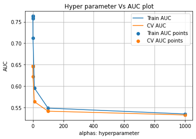

|  | mean_fit_time | std_fit_time | mean_score_time | std_score_time | param_alpha | split0_test_score | split1_test_score | split2_test_score | mean_test_score | std_test_score | rank_test_score | split0_train_score | split1_train_score | split2_train_score | mean_train_score | std_train_score | params |
| --- | --- | --- | --- | --- | --- | --- | --- | --- | --- | --- | --- | --- | --- | --- | --- | --- | --- |
| 0 | 0.611533 | 0.016319 | 0.124663 | 0.001503 | 0.0001 | 0.652172 | 0.633897 | 0.652875 | 0.646315 | 0.008785 | 3 | 0.766636 | 0.763938 | 0.758880 | 0.763152 | 0.003215 | 0.0001 |
| 1 | 0.591540 | 0.005644 | 0.123307 | 0.000909 | 0.001 | 0.652421 | 0.633950 | 0.652850 | 0.646407 | 0.008810 | 2 | 0.766594 | 0.763890 | 0.758833 | 0.763105 | 0.003217 | 0.0010 |
| 2 | 0.590564 | 0.000622 | 0.124295 | 0.001074 | 0.01 | 0.653011 | 0.633945 | 0.652633 | 0.646529 | 0.008900 | 1 | 0.766151 | 0.763377 | 0.758342 | 0.762623 | 0.003232 | 0.0100 |
| 3 | 0.591205 | 0.006442 | 0.122157 | 0.000440 | 0.1 | 0.652245 | 0.632320 | 0.650585 | 0.645050 | 0.009027 | 4 | 0.761500 | 0.758273 | 0.753236 | 0.757670 | 0.003401 | 0.1000 |
| 4 | 0.593820 | 0.007279 | 0.125441 | 0.004302 | 1 | 0.628957 | 0.611316 | 0.625949 | 0.622074 | 0.007705 | 5 | 0.716993 | 0.713821 | 0.706915 | 0.712576 | 0.004208 | 1.0000 |

```python
# https://scikit-learn.org/stable/modules/generated/sklearn.model_selection.GridSearchCV.html
from sklearn.model_selection import GridSearchCV
from scipy.stats import randint as sp_randint
from sklearn.model_selection import RandomizedSearchCV

NB = MultinomialNB()
alphas =  np.array([0.0001*pow(10,i) for i in range(8)])
parameters = {'alpha':alphas}
clf = RandomizedSearchCV(NB, parameters, cv=3, scoring='roc_auc',return_train_score=True)
clf.fit(X_tr2, y_train)

results = pd.DataFrame.from_dict(clf.cv_results_)

alphas_li = [row['params']['alpha'] for i, row in results.iterrows()]

results = results.drop(['params'], axis=1)

alphas_df= pd.DataFrame({'params':alphas_li})

frames = [results, alphas_df]

results = pd.concat(frames,axis=1)

results = results.sort_values(by = ['params'])

train_auc= results['mean_train_score']
train_auc_std= results['std_train_score']
cv_auc = results['mean_test_score']
cv_auc_std= results['std_test_score']
alphas =  results['params']

plt.plot(alphas, train_auc, label='Train AUC')
# this code is copied from here: https://stackoverflow.com/a/48803361/4084039
# plt.gca().fill_between(K, train_auc - train_auc_std,train_auc + train_auc_std,alpha=0.2,color='darkblue')

plt.plot(alphas, cv_auc, label='CV AUC')
# this code is copied from here: https://stackoverflow.com/a/48803361/4084039
# plt.gca().fill_between(K, cv_auc - cv_auc_std,cv_auc + cv_auc_std,alpha=0.2,color='darkorange')

plt.scatter(alphas, train_auc, label='Train AUC points')
plt.scatter(alphas, cv_auc, label='CV AUC points')


plt.legend()
plt.xlabel("alphas: hyperparameter")
plt.ylabel("AUC")
plt.title("Hyper parameter Vs AUC plot")
plt.grid()
plt.show()

results.head()
```

#### 1.5.1.2 Testing the performance of the model on test data, plotting ROC Curves

```python
#here we are choosing the best_alpha based on forloop results
best_alpha = clf.best_params_['alpha']
print(f'Best alpha found to be {best_alpha}')
```

```
Best alpha found to be 0.01
```

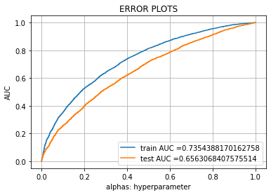

```python
# https://scikit-learn.org/stable/modules/generated/sklearn.metrics.roc_curve.html#sklearn.metrics.roc_curve
from sklearn.metrics import roc_curve, auc

NB = MultinomialNB(alpha = best_alpha)
#neigh = KNeighborsClassifier(n_neighbors=best_k, n_jobs=-1)
NB.fit(X_tr2, y_train)
# roc_auc_score(y_true, y_score) the 2nd parameter should be probability estimates of the positive class
# not the predicted outputs

y_train_pred = batch_predict(NB, X_tr2)
y_test_pred = batch_predict(NB, X_te2)

train_fpr, train_tpr, tr_thresholds = roc_curve(y_train, y_train_pred)
test_fpr, test_tpr, te_thresholds = roc_curve(y_test, y_test_pred)

plt.plot(train_fpr, train_tpr, label="train AUC ="+str(auc(train_fpr, train_tpr)))
plt.plot(test_fpr, test_tpr, label="test AUC ="+str(auc(test_fpr, test_tpr)))
plt.legend()
plt.xlabel("alphas: hyperparameter")
plt.ylabel("AUC")
plt.title("ERROR PLOTS")
plt.grid()
plt.show()
```

```python
# we are writing our own function for predict, with defined thresould
# we will pick a threshold that will give the least fpr
def find_best_threshold(threshould, fpr, tpr):
    t = threshould[np.argmax(tpr*(1-fpr))]
    # (tpr*(1-fpr)) will be maximum if your fpr is very low and tpr is very high
    print("the maximum value of tpr*(1-fpr)", max(tpr*(1-fpr)), "for threshold", np.round(t,3))
    return t

def predict_with_best_t(proba, threshould):
    predictions = []
    for i in proba:
        if i>=threshould:
            predictions.append(1)
        else:
            predictions.append(0)
    return predictions
```

```
====================================================================================================
the maximum value of tpr*(1-fpr) 0.4503786175775199 for threshold 0.847
Train confusion matrix
```

[figure not shown]

```
Test confusion matrix
```

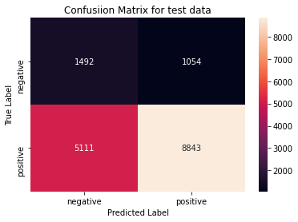

```python
print("="*100)
from sklearn.metrics import confusion_matrix
best_t = find_best_threshold(tr_thresholds, train_fpr, train_tpr)
print("Train confusion matrix")
Confusion_matrix(y_train, predict_with_best_t(y_train_pred, best_t))
print("Test confusion matrix")
Confusion_matrix(y_test, predict_with_best_t(y_test_pred, best_t))
```

```python
top_20_features(list_vectorizer,X_tr2,y_train,0.01)
```

```
Top 20 Negative Features:-
 performingarts                     -3.696321
warmth_care_hunger                 -3.902569
socialsciences                     -3.994793
specialneeds_visualarts            -4.146465
health_sports_warmth_care_hunger   -4.645724
literacy_language                  -4.755141
teamsports                         -4.806686
to                                 -4.892712
ca                                 -4.973409
and                                -5.051434
history_civics_literacy_language   -5.128339
the                                -5.165518
visualarts                         -5.209471
other_specialneeds                 -5.296020
appliedlearning                    -5.364747
students                           -5.367749
tx                                 -5.476709
of                                 -5.601691
in                                 -5.664642
health_wellness_teamsports         -5.675108
Name: 0, dtype: float64

 Top 20 Positive Features:-
 performingarts                     -3.664754
warmth_care_hunger                 -3.929461
socialsciences                     -4.040411
specialneeds_visualarts            -4.091937
health_sports_warmth_care_hunger   -4.503347
teamsports                         -4.881043
to                                 -4.895322
ca                                 -4.931833
literacy_language                  -4.934782
history_civics_literacy_language   -5.015992
and                                -5.052487
the                                -5.148065
visualarts                         -5.283528
students                           -5.338931
other_specialneeds                 -5.348073
appliedlearning                    -5.368277
health_wellness_other              -5.387831
health_wellness_teamsports         -5.567072
of                                 -5.611063
ny                                 -5.699153
Name: 1, dtype: float64
```

# 3. Summary

as mentioned in the step 5 of instructions

```python
from prettytable import PrettyTable

x = PrettyTable()

x.field_names = ["Vectorizer", "Model", "Hyper parameter", "AUC"]

x.add_row(["BOW", "NaiveBayes", 0.01, 0.685])
x.add_row(["TFIDF", "NaiveBayes", 0.01, 0.656])

print(x)
```

```
+------------+------------+-----------------+-------+
| Vectorizer |   Model    | Hyper parameter |  AUC  |
+------------+------------+-----------------+-------+
|    BOW     | NaiveBayes |       0.01      | 0.685 |
|   TFIDF    | NaiveBayes |       0.01      | 0.656 |
+------------+------------+-----------------+-------+
```